# Chordates only - 185 CS

2023-10-11

## Script to work on analyses for causes paper

##Taxonomic work is needed? # Morpho differentiation types: More CS sl than CS ss overall? # Need to find expectations and test against 50:50 mark

```
##
##  Pearson's Chi-squared test with Yates' continuity correction
##
## data:  cbind(expected, observed)
## X-squared = 7.2121, df = 1, p-value = 0.007241
```

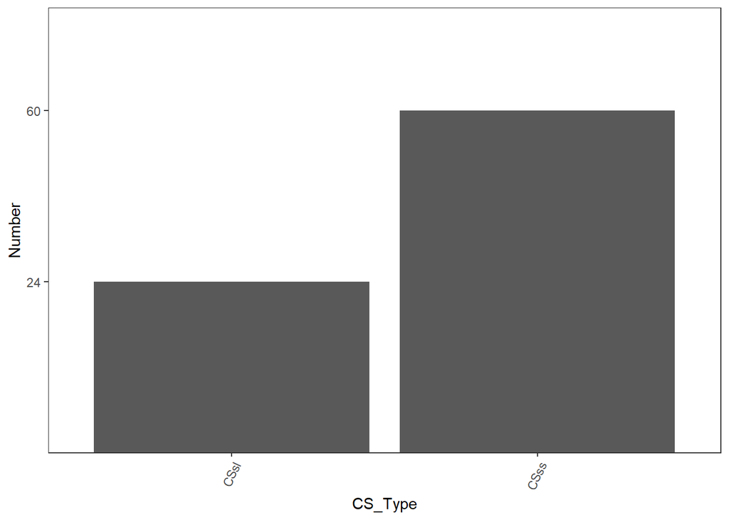

More CSss than the 50% benchmark (significant), so reject the idea that most CS are just due to taxonomic oversight.

# Available technology – More diagnostic differences in species described earlier?

```
##
##        FALSE TRUE
##   1750     0    6
##   1760     1    1
##   1770     0    1
##   1780     0    2
##   1800     2    2
##   1810     1    1
##   1820     2    3
##   1830     0    6
##   1840     0    8
##   1850     1    3
##   1860     0    1
##   1870     1    3
##   1880     2    0
##   1890     0    2
##   1900     0    2
##   1910     1    1
##   1920     1    1
##   1930     2    1
##   1940     1    0
##   1950     1    2
##   1960     1    1
##   1970     1    0
##   1990     1    0
##   2000     0    3
##   2010     3    4
```

```
##
##  Pearson's Chi-squared test
##
## data:  decademorpho$decade and decademorpho$CSss
## X-squared = 31.039, df = 24, p-value = 0.1527
```

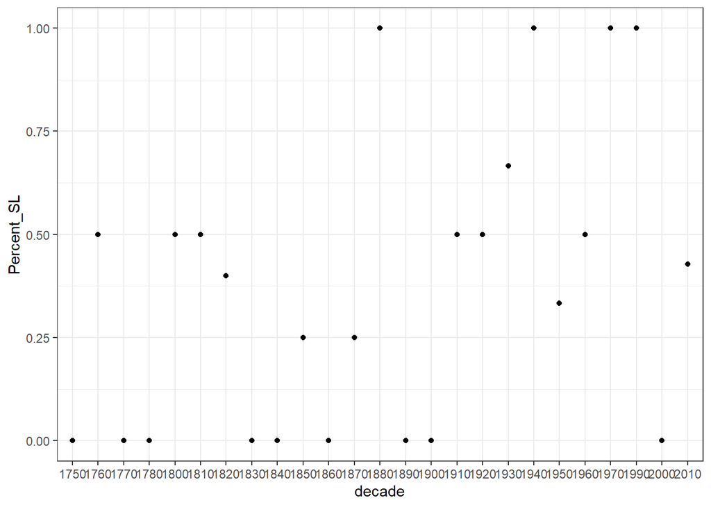

There is no trend in the percent of CSsl (diagnostic differences) through time; hypothesis not supported.

# Prevailing theories of nature and species origins - More CS in fragmented habitats in species described before Darwin?

```
##
##             10 100 1000 25  5
##   1756-1859 32   2   33  9  6
##   1860-1980 16   3   12  7  3
##   1981-2020 13   1    4  3  1
```

```
##
##  Pearson's Chi-squared test
##
## data:  breaks_HKK$decade_bin and breaks_HKK$HKK
## X-squared = 7.2023, df = 8, p-value = 0.515
```

```
##                   10        100      1000        25          5
## pre_Darwin 0.3902439 0.02439024 0.4024390 0.1097561 0.07317073
## pre_Kimura 0.3902439 0.07317073 0.2926829 0.1707317 0.07317073
## modern     0.5909091 0.04545455 0.1818182 0.1363636 0.04545455
```

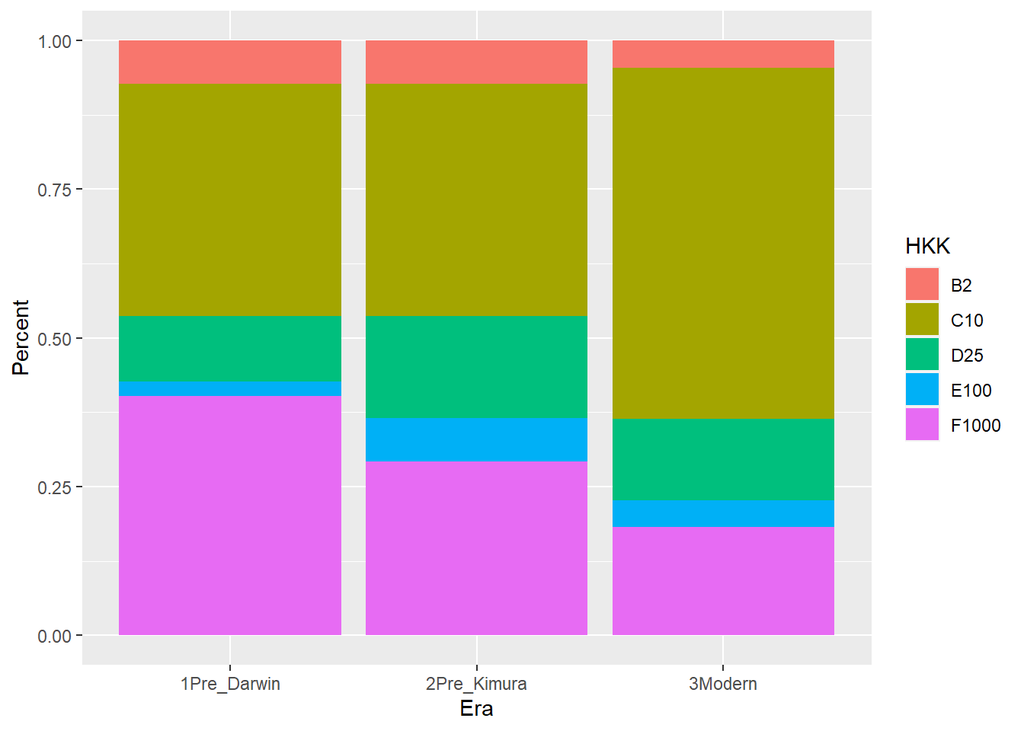

# Accessibility of habitat when species described - Percentage of CS in inaccessible habitats higher in earlier spp?

```
##
##        Difficult Easy Normal
##   1750         0    1     12
##   1760         0    1      2
##   1770         1    0      3
##   1780         0    1      5
##   1790         0    1      6
##   1800         0    0      8
##   1810         0    1      1
##   1820         1    0     11
##   1830         1    2     13
##   1840         0    0     12
##   1850         0    2      9
##   1860         0    0      2
##   1870         0    1      6
##   1880         1    1      4
##   1890         0    0      3
##   1900         0    0      6
##   1910         1    0      1
##   1920         0    0      3
##   1930         0    0      4
##   1940         0    0      2
##   1950         1    0      5
##   1960         0    0      4
##   1970         2    0      2
##   1980         0    0      1
##   1990         0    0      2
##   2000         1    1     10
##   2010         1    0      8
```

```
##
##  Pearson's Chi-squared test
##
## data:  decadeAccess$decade and decadeAccess$Access
## X-squared = 52.338, df = 52, p-value = 0.4608
```

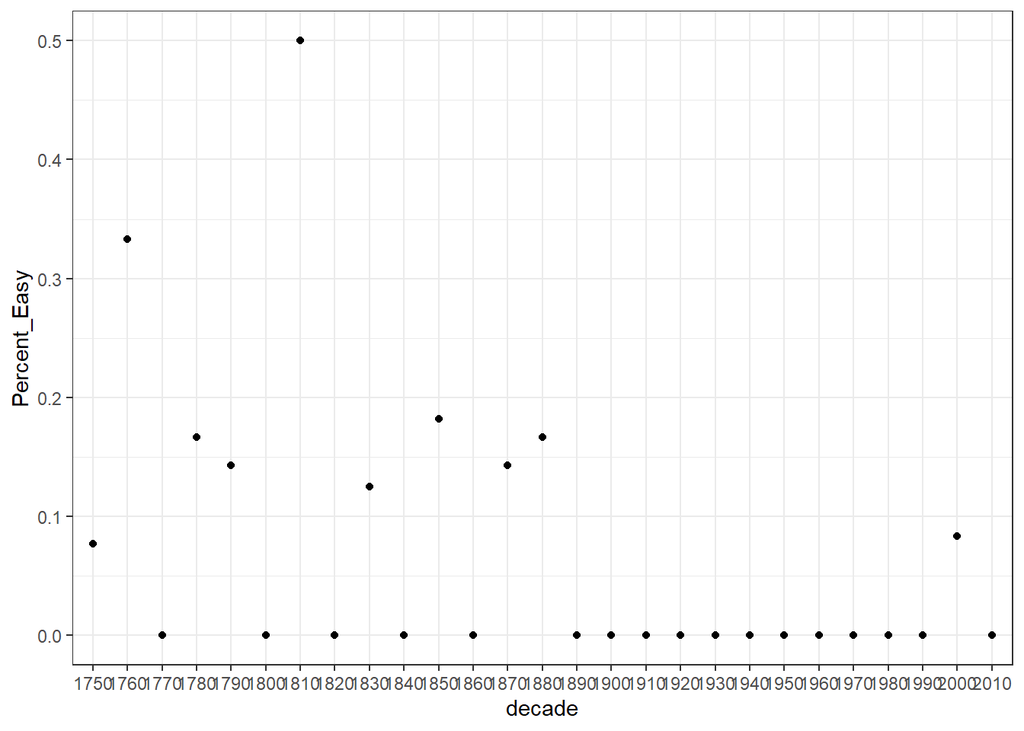

So the result is not significant but the graph is very much in line with our predictions - easy species mostly described early. Not many of those, though.

## In sum, when we only look at species with CS (i.e. our database), the effect of taxonomic work goes away. This is interesting since that was the strongest effect in paper 1. Seems to still be true with the chordates.

## Effect of recent divergence - dispersal

# Larval type – Planktotrophic/pelagic larvae leads to less CS/NS)?

Note1: for this I’m working with a separate surveylarv input file where I have corrected larval types to pt, lt, dd, and removed all others, including cases where there are multiple types checked. (Most of those cases are where the two CS have different larvae.) This left 129 CS with larval info.

Note2: the data fail the homoscedasticity test (Bartlett’s) so I’ve used a nonparametric Kruskal-Wallis test to see if CS/NS is different among groups.

```
##       DD       LT       PT
## 2.823529 2.583333 3.210000
```

```
##       DD       LT       PT
## 1.590412 1.083625 3.809332
```

```
##
##  Kruskal-Wallis rank sum test
##
## data:  as.numeric(larv_NbCS$Nb_CS) and larv_NbCS$Larv_type
## Kruskal-Wallis chi-squared = 0.379, df = 2, p-value = 0.8274
```

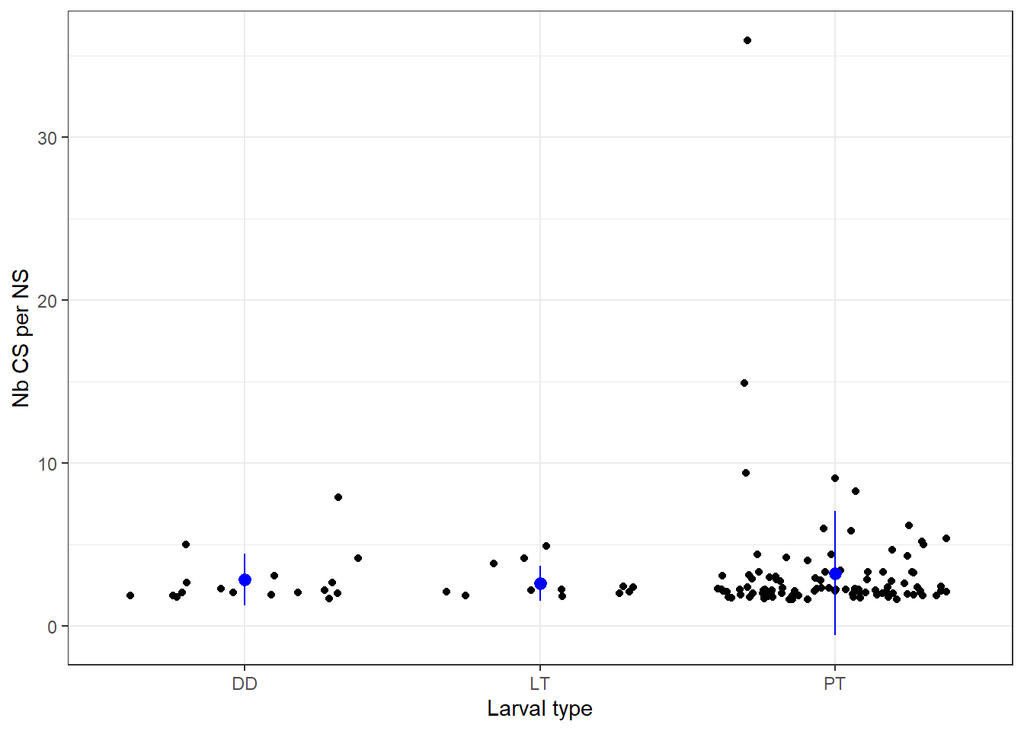

Hypothesis not supported. Way more species with planktotrophic larvae here.

# High HKK leads to more CS ss – testing this based on Nb_CS per HKK.

Note: data again failed homoscedasticity, using Kruskal Wallis test

```
##        5       10       25      100     1000
## 2.400000 3.200000 2.526316 3.142857 3.456140
```

```
##         5        10        25       100      1000
## 0.6992059 2.2367160 0.8411910 2.6095064 5.0145153
```

```
##
##  Kruskal-Wallis rank sum test
##
## data:  HKK_NbCS$Nb_CS and HKK_NbCS$HKKv3
## Kruskal-Wallis chi-squared = 3.4424, df = 4, p-value = 0.4867
```

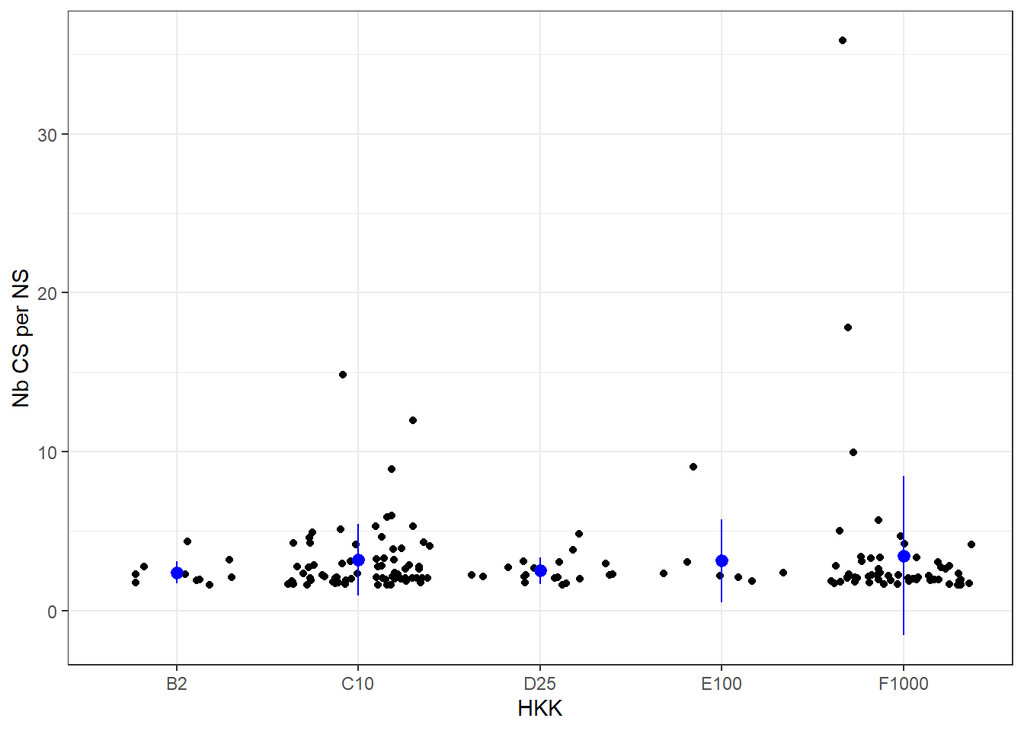

## In sum, NO support for the role of recent divergence as measured by a proxy of dispersal when considering only chordates. Note small sample size, and that most chordates are either ascidians or bony fish.

# More stable environments = more CSss or statistical differences

Note: stable = pelagic, deepsea, cave, coralreef; not stable = coastal, intertidal, estuarine, seagrass

```
##
##         FALSE TRUE
##   FALSE    10   14
##   TRUE     30   30
```

```
##
##  Pearson's Chi-squared test with Yates' continuity correction
##
## data:  stable_hab$CSss and stable_hab$Stable
## X-squared = 0.20165, df = 1, p-value = 0.6534
```

```
##            FALSE      TRUE
## CSss_total  0.75 0.6818182
## CSsl_total  0.25 0.3181818
```

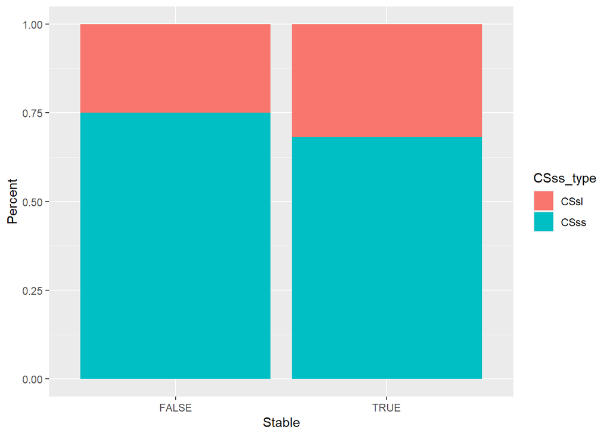

Result: More CSss NOT found in stable environments. Hypothesis NOT supported.

# Note also that stabilizing selection predicts more CSss than CSsl, which is what we find (see above).

## In sum, we have mixed support for this idea.

## High Ne (neutral hypotheses)

# Reproductive investment - Low reproductive investment leads to more statistical divergence? (Repro. investment proxy for Ne)

Note1: Again this uses the surveylarv dataset with hand cleaning. Note2: Planktotrophic = LOW; Lecithotrophic, Brooding, DD = HIGH; If a spp could be both low and high, have marked it NA (is usually bc the CS have different larval types). Anything else got marked NA to be conservative. Note3: Only 62 cases are considered here, meaning that is where we have morphological data AND larval type data AND chordates! Small sample size!

```
##
##                      HIGH LOW
##   Diagnostic           10   9
##   No differentiation    2  12
##   Statistic             6  23
```

```
##
##  Pearson's Chi-squared test
##
## data:  surveylarv2$Morpho_diff and surveylarv2$Repro_invest
## X-squared = 7.5931, df = 2, p-value = 0.02245
```

```
##                 HIGH       LOW
## stat_total 0.3333333 0.5227273
## diag_total 0.5555556 0.2045455
## nod_total  0.1111111 0.2727273
```

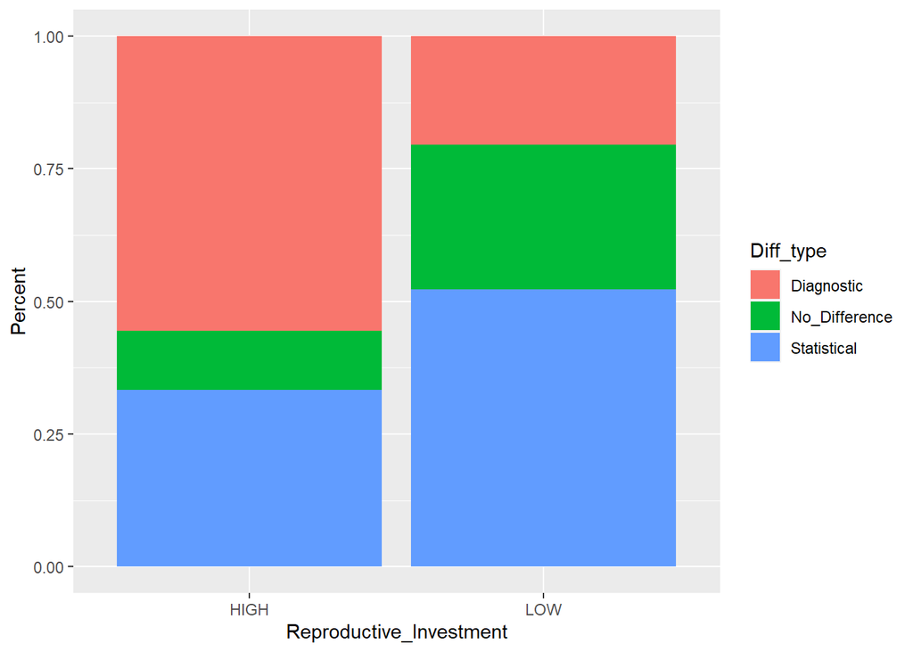

Result: significant. Hypothesis supported - lots more diagnostic differences with high reproductive investment. This is very different than at the whole dataset level!

# High HKK leads to more CS ss (HKK as proxy for Ne)

```
##
##                       5 10 25 100 1000
##   Diagnostic          3 11  6   1    3
##   No differentiation  0  8  2   0    3
##   Statistic           2 15  4   3   12
```

```
##              5        10        25  100      1000
## stat_total 0.4 0.4411765 0.3333333 0.75 0.6666667
## diag_total 0.6 0.3235294 0.5000000 0.25 0.1666667
## nod_total  0.0 0.2352941 0.1666667 0.00 0.1666667
```

```
##
##    5   10   25  100 1000
##    5   34   12    4   18
```

```
##
##  Pearson's Chi-squared test
##
## data:  surveymorpho$Morpho_diff and surveymorpho$HKKv3
## X-squared = 8.4854, df = 8, p-value = 0.3875
```

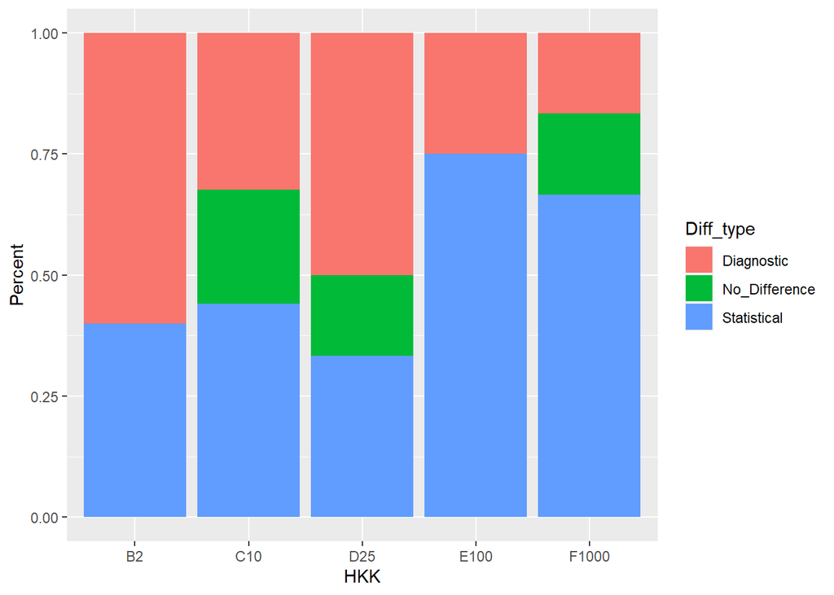

```
##
##        FALSE TRUE
##   5        3    2
##   10      11   23
##   25       6    6
##   100      1    3
##   1000     3   15
```

```
##
##  Pearson's Chi-squared test
##
## data:  surveymorpho$HKKv3 and surveymorpho$CSss
## X-squared = 5.5212, df = 4, p-value = 0.2379
```

```
##              5        10  25  100      1000
## CSss_total 0.4 0.6764706 0.5 0.75 0.8333333
## CSsl_total 0.6 0.3235294 0.5 0.25 0.1666667
```

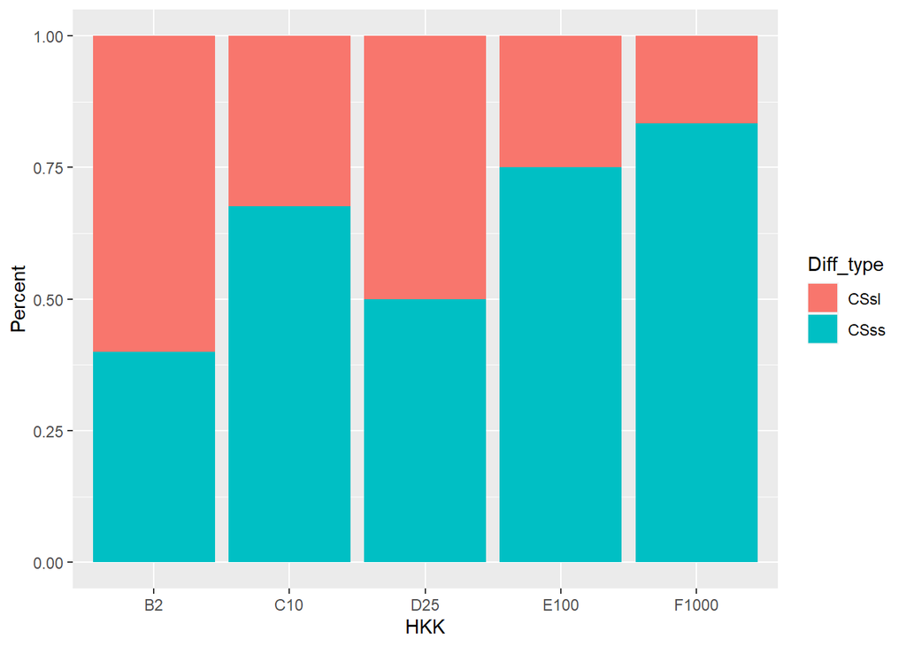

Results: No longer significant, either with 3 morpho types OR when testing CSss vs sl. But, trend towards more ss cases in higher HKK, which does support the hypothesis.

## In sum, we see support for the neutral hypothesis with BOTH reproductive investment and HKK.

## Hypothesis: effect of recent divergence – More sympatric than allopatric CS/NS for a given Nsg?

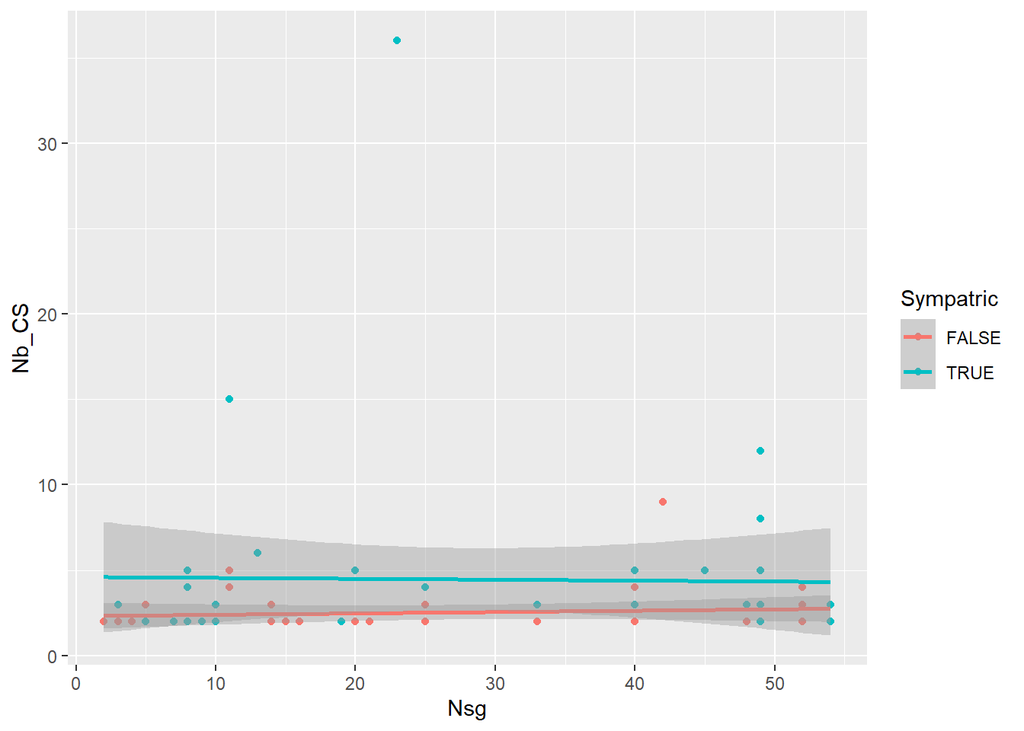

```
## ANOVA Table (type II tests)
##
##      Effect DFn DFd       F     p p<.05      ges
## 1     Nb_CS   1  77 0.00095 0.975       1.23e-05
## 2 Sympatric   1  77 0.11400 0.736       1.00e-03
```

These results aren’t statistically significant (ANCOVA) but the graph is in line with the hypothesis. HOWEVER, error overlaps a lot. Marginal support.

## Selection against hybrids – More diagnostic differences in sympatry than allopatry?

```
##
##         FALSE TRUE
##   FALSE    10    6
##   TRUE     21   15
```

```
##
##  Pearson's Chi-squared test with Yates' continuity correction
##
## data:  surveymorpho$CSss and surveymorpho$Sympatric
## X-squared = 1.0362e-30, df = 1, p-value = 1
```

```
##                FALSE      TRUE
## CSss_total 0.6774194 0.7142857
## CSsl_total 0.3225806 0.2857143
```

[figure not shown]

Result: Not supported. Very small sample size here, just 52 cases.

## Importance of biological traits

# More diagnostic traits with hard skeleton?

```
##
##                       N  Y
##   Diagnostic          8 16
##   No differentiation  1 15
##   Statistic           2 42
```

```
##
##  Pearson's Chi-squared test
##
## data:  surveymorpho$Morpho_diff and surveymorpho$hard_skeleton
## X-squared = 12.123, df = 2, p-value = 0.002331
```

```
##                     N         Y
## stat_total 0.18181818 0.5753425
## diag_total 0.72727273 0.2191781
## nod_total  0.09090909 0.2054795
```

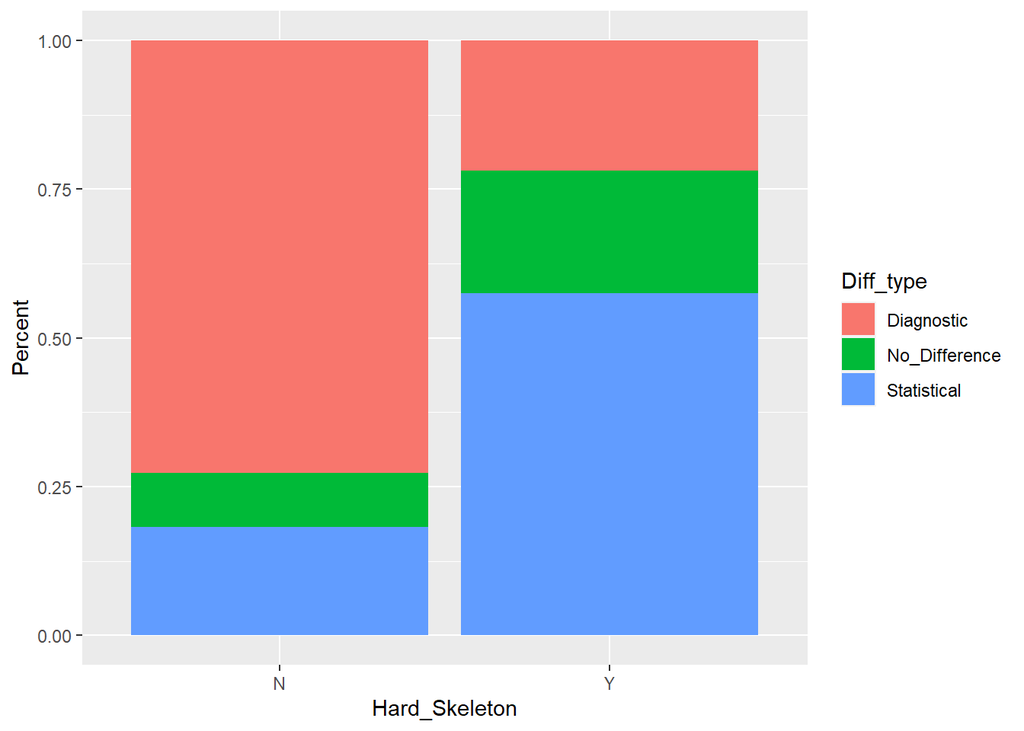

Very significant here, but in a direction OPPOSITE what is expected. I wonder if this has to do with fish vs ascidians - are ascidians more likely to be diagnostic? Look into.

# More diagnostic traits with image vision?

```
##
##                       N  Y
##   Diagnostic          8 16
##   No differentiation  1 15
##   Statistic           2 42
```

```
##
##  Pearson's Chi-squared test
##
## data:  surveymorpho$Morpho_diff and surveymorpho$image
## X-squared = 12.123, df = 2, p-value = 0.002331
```

Result: results again in a direction OPPOSITE what is expected. Same values as above, because image vision and skeleton are linked traits in chordates. Basically, fish are more likely to be statistically differentiated and ascidians are more likely to be diagnostically different.

# More diagnostic traits with internal fertilization?

```
##
##                       B  E  I
##   Diagnostic          8 13  3
##   No differentiation  1 14  1
##   Statistic           2 34  8
```

```
##
##  Pearson's Chi-squared test
##
## data:  surveymorpho$Morpho_diff and surveymorpho$ferti
## X-squared = 13.524, df = 4, p-value = 0.008981
```

```
##                     B         E          I
## stat_total 0.18181818 0.5573770 0.66666667
## diag_total 0.72727273 0.2131148 0.25000000
## nod_total  0.09090909 0.2295082 0.08333333
```

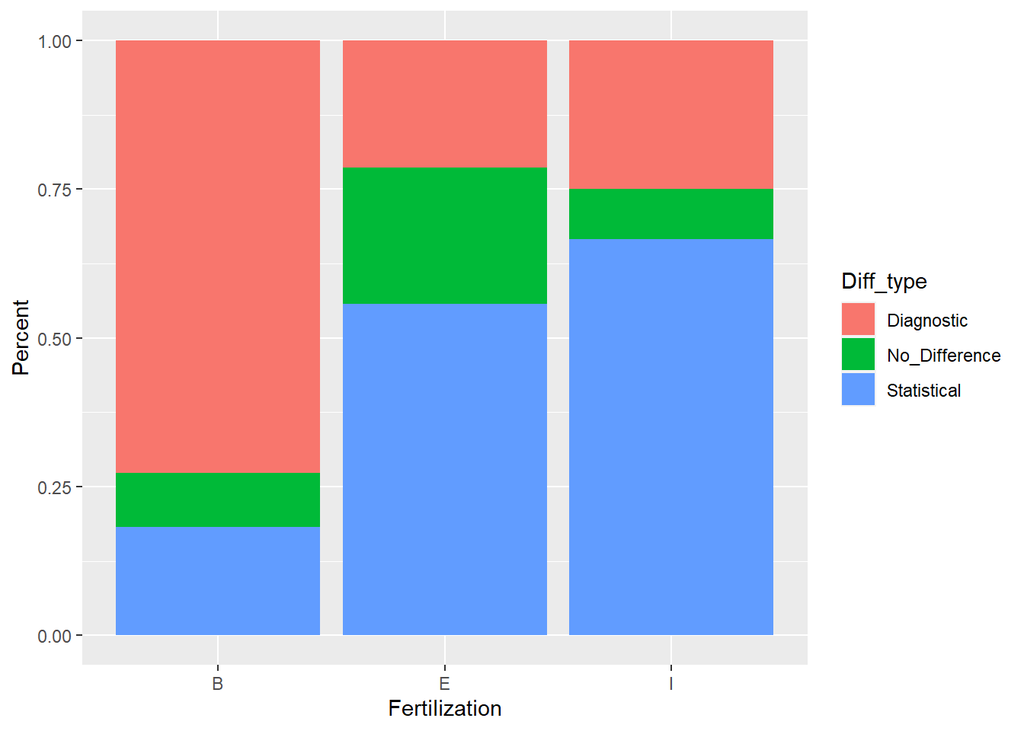

Result: SAME AS ABOVE - significant but in direction opposite expectations; correlated / linked with class, because ascidians are ‘both’.

# More diagnostic traits with external genitalia?

```
##
##                       B  N  Y
##   Diagnostic          0 21  3
##   No differentiation  0 15  1
##   Statistic           0 36  8
```

```
##
##  Pearson's Chi-squared test
##
## data:  surveymorpho$Morpho_diff and surveymorpho$genitals
## X-squared = 1.4517, df = 2, p-value = 0.4839
```

```
##              B         N          Y
## stat_total NaN 0.5000000 0.66666667
## diag_total NaN 0.2916667 0.25000000
## nod_total  NaN 0.2083333 0.08333333
```

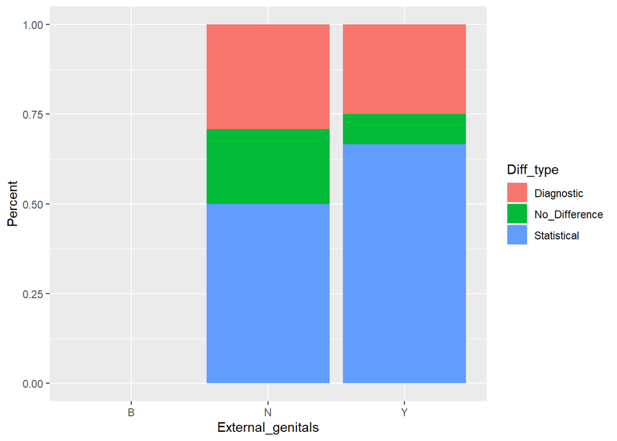

Result: hypothesis not supported.

## In sum, within chordates the biological traits appear important but we need to also consider taxonomy, which is confounded here.

## So, overall conclusions: When looking at just the chordates, many patterns have changed relative to the whole dataset. Most notably, we now have support for reproductive investment but have lost support for biological factors (and HKK?) within the class.